# Project: Climate in Guatemala

Andrea Sofía García de León

October, 2019

## Introduction

This is an example of an R Markdown document. It presents information about climate in Guatemala. The data was obtained from WorldClim.

## Guatemala

Guatemala is a country in Central America. Its official area is 108,889 km². The borders of Guatemala are shown on the map.

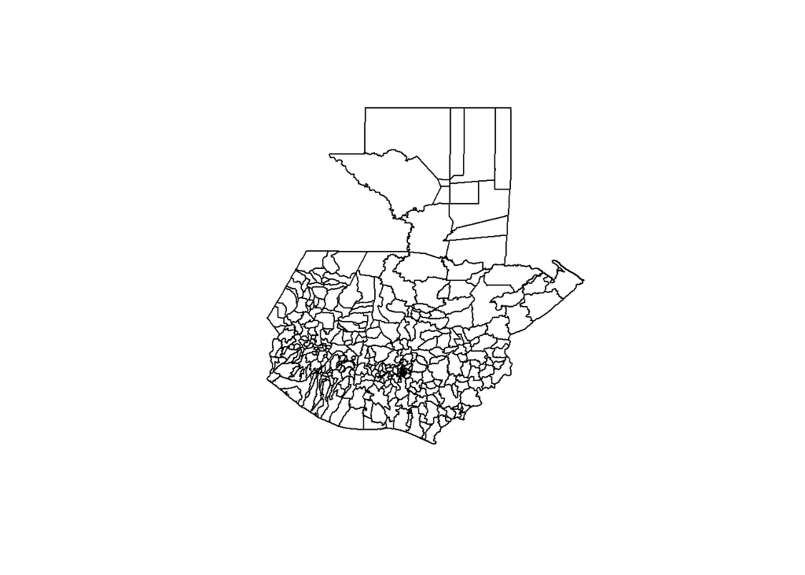

Source: GADM

Guatemala is mountainous except for the south coast and the vast northern lowlands of Peten. All major cities are located in the highlands and Pacific coast regions. These regions vary in climate, elevation, and landscape, providing dramatic contrasts between humid tropical weather in the Pacific Coast and Peten, and colder, drier weather in the highland peaks.

### Precipitation

Guatemala’s location between the Atlantic and Pacific Ocean makes it proned to humid tropical climate. The dinamic of rainfall is shown in the sequence.

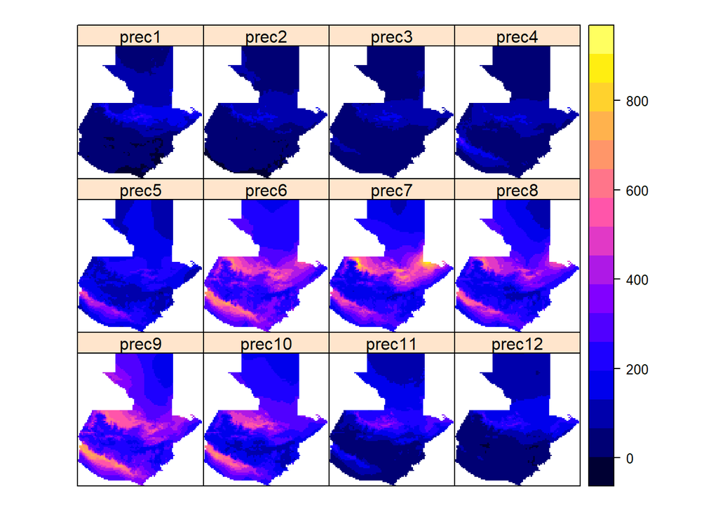

Source: WorldClim

As it is shown in the graph, the rainy season starts in May and ends in October. There is a canicula in July and Agoust.

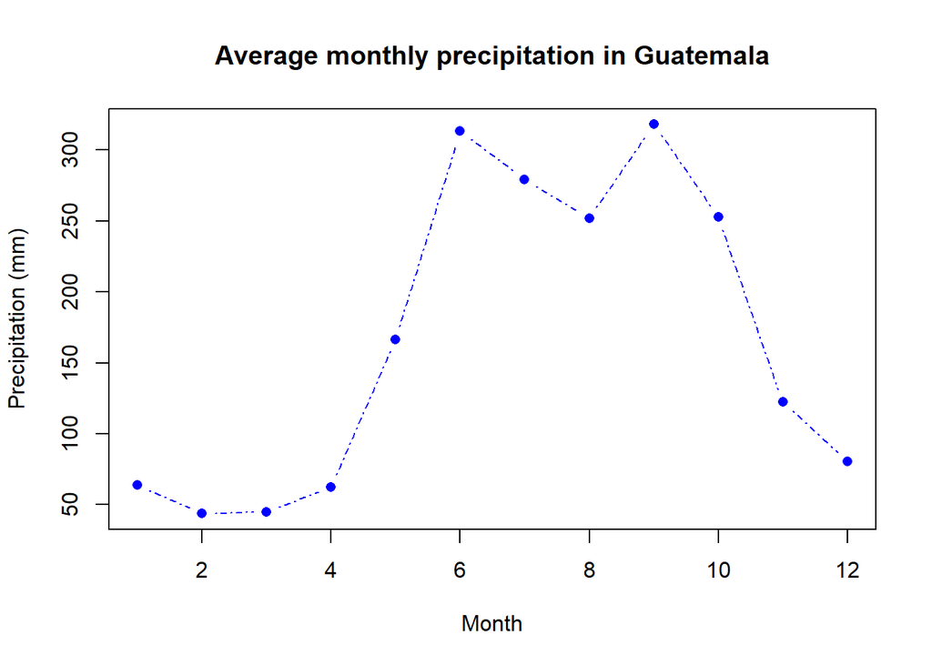

### Temperature

The dinamic of mean monthly temperature is shown in the following sequence.

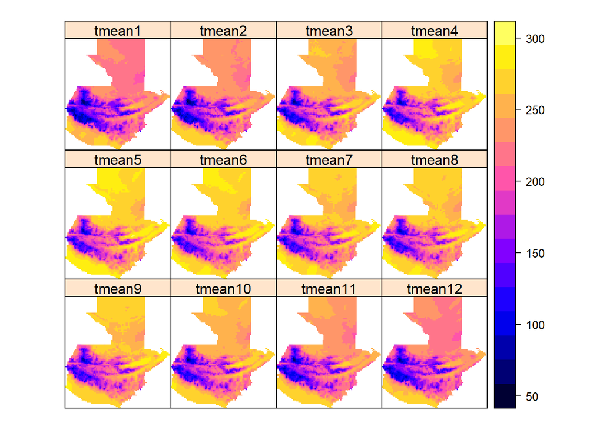

Source: WorldClim

The average mean monthly temperature is shown in the graphic. The temperature is shown in °C *10. The warm season is from March to July. The hottest month is May.

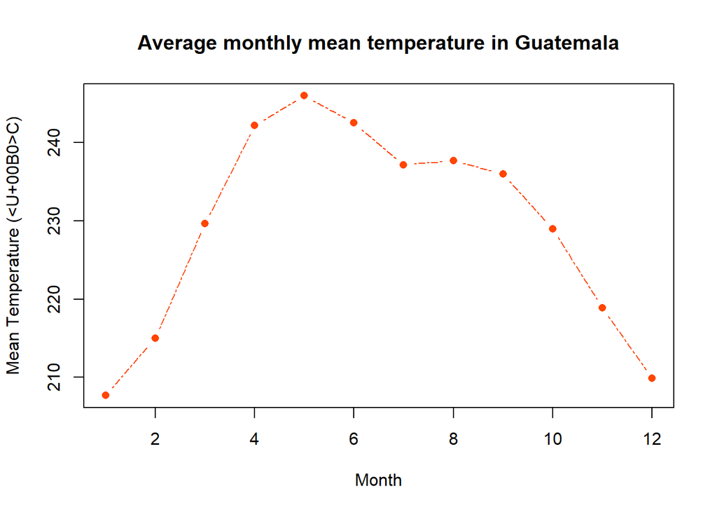